[figure not shown]

WI-432

Bulkhead Wiring Harness (In Compartment) RH

WIRING SYSTEM

64.Bulkhead Wiring Harness (In Compartment) RH

A: LOCATION

1. ENGINE TYPE FA

Connector Connecting to

No. Pole Color Area No. Description

AB6 30 Y D-2 Airbag CM

AB9 4 Y D-2 Passenger’s airbag module

AB65 2 D-3 B556

Bulkhead wiring harness

AD11 2 D-3 B579

AD12 3 D-3 Keyless access interior antenna (front)

B30 8 B C-5 D1 Front door cord RH

B57 4 B-2 Power transistor

B87 2 B-4 Blower motor

B88 2 BR B-2 Evaporator sensor

B90 17 GR A-5 R50 Roof cord

B97 20 C-5 R1 Rear wiring harness RH

B116 8 D-3 Select lever

B163 6 B B-4 Intake door actuator

B220 44 B-3 Relay holder

B239 6 C-2 Air mix door actuator RH

B358 2 D-3 Select lever illumination

B386 4 C-4 Blower motor relay

B556 2 D-3 AB65 Airbag wiring harness

B579 2 D-3 AD11 Keyless access interior antenna adapter cord

B583 12 C-3 i237

Instrument panel wiring harness

B584 20 C-3 i238

: White or natural color

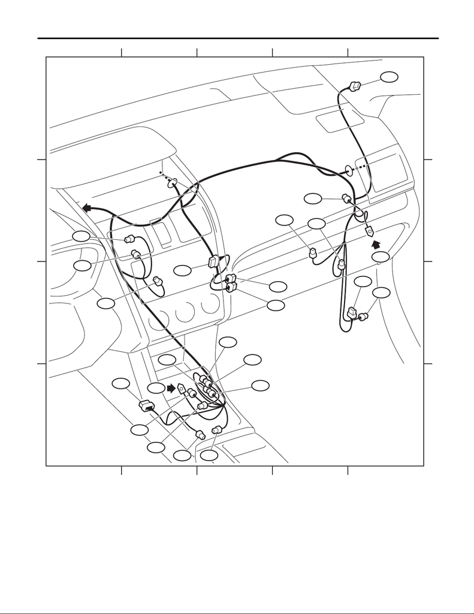

WI-433

Bulkhead Wiring Harness (In Compartment) RH

WIRING SYSTEM

WI-44616

12345

12345

A

B

C

D

A

B

C

D

LH

AD11

B579

AB65

B 556

AB9

AD12

AB6

GB-4

B583

B584

B220

B116

B88

B57

B358

B239

B97

B30

GB-6

B386

B163

B87

B90

[figure not shown]

WI-434

Bulkhead Wiring Harness (In Compartment) RH

WIRING SYSTEM

2. ENGINE TYPE EJ

Connector Connecting to

No. Pole Color Area No. Description

AB6 30 Y D-2 Airbag CM

AB9 4 Y D-2 Passenger’s airbag module

AB65 2 D-3 B556 Bulkhead wiring harness

AD12 3 D-3 Keyless access interior antenna (front)

AD13 10 GR B4 D-2 Bulkhead wiring harness

AD14 2 D-3 STI illumination

B1 6 B-3 J/C

B4 10 B D-2 AD13 Inside front antenna adapter cord

B30 8 B C-5 D1 Front door cord RH

B57 4 B-2 Power transistor

B83 6 B-2 J/C

B87 2 B-4 Blower motor

B88 2 BR B-2 Evaporator sensor

B90 17 GR A-5 R50 Roof cord

B97 20 C-5 R1 Rear wiring harness RH

B122 8 B-3 J/C

B134 34 B-3

ECM

B135 35 B-3

B136 35 B-2

B137 31 B-2

B163 6 B B-4 Intake door actuator

B220 44 B-3 Relay holder

B239 6 C-2 Air mix door actuator RH

B358 2 D-3 Select lever illumination

B380 32 C-2 DCCD CM

B386 4 C-4 Blower motor relay

B556 2 D-3 AB65 Airbag wiring harness

B583 12 C-3 i237

Instrument panel wiring harness

B584 20 C-3 i238

: White or natural color

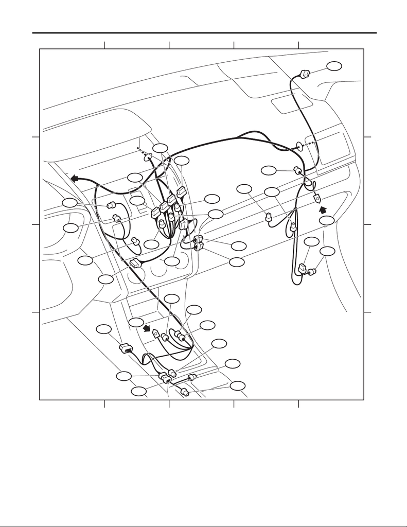

WI-435

Bulkhead Wiring Harness (In Compartment) RH

WIRING SYSTEM

WI-44618

12345

12345

A

B

C

D

A

B

C

D

LH

B386

B163

B90

B97

B30

B87

B134

B556

AB65

AB9

B135

B136

B137

AB6

B583

B584

B122

B1

B220

B83

B88

B57

B239

B380

B4

AD13

AD14

B358

AD12

GB-4

GB-6